# Day 1 Notebook: Predicting Toronto's Weather

## Let's create a new model, that looks into the future.

```python
model = keras.Sequential([
    layers.Dense(32, activation='relu', input_shape=(X_train.shape[1],)),
    layers.Dense(1)
])

model.compile(optimizer='adam', loss='mse', metrics=['mae'])

history = model.fit(
    X_train, y_train,
    validation_split=0.1,
    epochs=175,
    batch_size=32,
    verbose=1
)
```

```
225/225 ━━━━━━━━━━━━━━━━━━━━ 0s 988us/step - loss: 218.2780 - mae: 11.6316 - val_loss: 117.1080 - val_mae: 9.1193
225/225 ━━━━━━━━━━━━━━━━━━━━ 0s 747us/step - loss: 106.5235 - mae: 8.6975 - val_loss: 109.6559 - val_mae: 8.8662
225/225 ━━━━━━━━━━━━━━━━━━━━ 0s 747us/step - loss: 96.0134 - mae: 8.1793 - val_loss: 90.9769 - val_mae: 7.9642
225/225 ━━━━━━━━━━━━━━━━━━━━ 0s 738us/step - loss: 78.9301 - mae: 7.4030 - val_loss: 73.8384 - val_mae: 7.1242
225/225 ━━━━━━━━━━━━━━━━━━━━ 0s 733us/step - loss: 62.5303 - mae: 6.4994 - val_loss: 57.5593 - val_mae: 6.2209
225/225 ━━━━━━━━━━━━━━━━━━━━ 0s 734us/step - loss: 46.5445 - mae: 5.5554 - val_loss: 43.4378 - val_mae: 5.2083
225/225 ━━━━━━━━━━━━━━━━━━━━ 0s 738us/step - loss: 35.3587 - mae: 4.7845 - val_loss: 31.9870 - val_mae: 4.4236
225/225 ━━━━━━━━━━━━━━━━━━━━ 0s 738us/step - loss: 26.9364 - mae: 4.0957 - val_loss: 26.8716 - val_mae: 3.9777
225/225 ━━━━━━━━━━━━━━━━━━━━ 0s 787us/step - loss: 22.0934 - mae: 3.7211 - val_loss: 23.5006 - val_mae: 3.6154
225/225 ━━━━━━━━━━━━━━━━━━━━ 0s 753us/step - loss: 21.2084 - mae: 3.6216 - val_loss: 23.4722 - val_mae: 3.6424
225/225 ━━━━━━━━━━━━━━━━━━━━ 0s 740us/step - loss: 21.2571 - mae: 3.6320 - val_loss: 21.1090 - val_mae: 3.4531
225/225 ━━━━━━━━━━━━━━━━━━━━ 0s 738us/step - loss: 20.7667 - mae: 3.6091 - val_loss: 26.6746 - val_mae: 3.9987
225/225 ━━━━━━━━━━━━━━━━━━━━ 0s 740us/step - loss: 21.4450 - mae: 3.6514 - val_loss: 20.1891 - val_mae: 3.3898
225/225 ━━━━━━━━━━━━━━━━━━━━ 0s 749us/step - loss: 19.9942 - mae: 3.5298 - val_loss: 26.2995 - val_mae: 3.9657
225/225 ━━━━━━━━━━━━━━━━━━━━ 0s 756us/step - loss: 19.7169 - mae: 3.5120 - val_loss: 19.7883 - val_mae: 3.3624
225/225 ━━━━━━━━━━━━━━━━━━━━ 0s 747us/step - loss: 19.3921 - mae: 3.4844 - val_loss: 21.3340 - val_mae: 3.5472
225/225 ━━━━━━━━━━━━━━━━━━━━ 0s 761us/step - loss: 19.9034 - mae: 3.5287 - val_loss: 20.0752 - val_mae: 3.4107
225/225 ━━━━━━━━━━━━━━━━━━━━ 0s 746us/step - loss: 20.0285 - mae: 3.5517 - val_loss: 20.1717 - val_mae: 3.4172
225/225 ━━━━━━━━━━━━━━━━━━━━ 0s 751us/step - loss: 20.2213 - mae: 3.5693 - val_loss: 20.5052 - val_mae: 3.4602
225/225 ━━━━━━━━━━━━━━━━━━━━ 0s 747us/step - loss: 20.9009 - mae: 3.6114 - val_loss: 19.3941 - val_mae: 3.3430
225/225 ━━━━━━━━━━━━━━━━━━━━ 0s 743us/step - loss: 20.9607 - mae: 3.6214 - val_loss: 20.4245 - val_mae: 3.4571
225/225 ━━━━━━━━━━━━━━━━━━━━ 0s 752us/step - loss: 19.8397 - mae: 3.5316 - val_loss: 23.6845 - val_mae: 3.7910
225/225 ━━━━━━━━━━━━━━━━━━━━ 0s 742us/step - loss: 20.1128 - mae: 3.5687 - val_loss: 19.3277 - val_mae: 3.3432
225/225 ━━━━━━━━━━━━━━━━━━━━ 0s 756us/step - loss: 20.1314 - mae: 3.5508 - val_loss: 19.4868 - val_mae: 3.3490
225/225 ━━━━━━━━━━━━━━━━━━━━ 0s 754us/step - loss: 20.0840 - mae: 3.5546 - val_loss: 20.6883 - val_mae: 3.4890
225/225 ━━━━━━━━━━━━━━━━━━━━ 0s 754us/step - loss: 19.4864 - mae: 3.4901 - val_loss: 19.8453 - val_mae: 3.3957
225/225 ━━━━━━━━━━━━━━━━━━━━ 0s 743us/step - loss: 19.9929 - mae: 3.5587 - val_loss: 19.4548 - val_mae: 3.3467
225/225 ━━━━━━━━━━━━━━━━━━━━ 0s 764us/step - loss: 19.5664 - mae: 3.4852 - val_loss: 20.3430 - val_mae: 3.4552
225/225 ━━━━━━━━━━━━━━━━━━━━ 0s 741us/step - loss: 20.8854 - mae: 3.6067 - val_loss: 19.6306 - val_mae: 3.3655
225/225 ━━━━━━━━━━━━━━━━━━━━ 0s 750us/step - loss: 20.0259 - mae: 3.5293 - val_loss: 19.7588 - val_mae: 3.3912
225/225 ━━━━━━━━━━━━━━━━━━━━ 0s 736us/step - loss: 20.2607 - mae: 3.5632 - val_loss: 21.1682 - val_mae: 3.5458
225/225 ━━━━━━━━━━━━━━━━━━━━ 0s 751us/step - loss: 19.3439 - mae: 3.4945 - val_loss: 19.8886 - val_mae: 3.4105
225/225 ━━━━━━━━━━━━━━━━━━━━ 0s 745us/step - loss: 19.4873 - mae: 3.5029 - val_loss: 19.9351 - val_mae: 3.3969
225/225 ━━━━━━━━━━━━━━━━━━━━ 0s 738us/step - loss: 20.8621 - mae: 3.5976 - val_loss: 19.3354 - val_mae: 3.3411
225/225 ━━━━━━━━━━━━━━━━━━━━ 0s 741us/step - loss: 19.7133 - mae: 3.5040 - val_loss: 19.5374 - val_mae: 3.3610
225/225 ━━━━━━━━━━━━━━━━━━━━ 0s 742us/step - loss: 19.5773 - mae: 3.4823 - val_loss: 19.4050 - val_mae: 3.3514
225/225 ━━━━━━━━━━━━━━━━━━━━ 0s 740us/step - loss: 20.1187 - mae: 3.5538 - val_loss: 19.4907 - val_mae: 3.3642
225/225 ━━━━━━━━━━━━━━━━━━━━ 0s 747us/step - loss: 20.1876 - mae: 3.5746 - val_loss: 19.4685 - val_mae: 3.3532
225/225 ━━━━━━━━━━━━━━━━━━━━ 0s 736us/step - loss: 19.9344 - mae: 3.5054 - val_loss: 19.1851 - val_mae: 3.3287
225/225 ━━━━━━━━━━━━━━━━━━━━ 0s 743us/step - loss: 19.2415 - mae: 3.4445 - val_loss: 19.8960 - val_mae: 3.4082
```

[output cut: 120 more lines]

```
225/225 ━━━━━━━━━━━━━━━━━━━━ 0s 731us/step - loss: 20.2047 - mae: 3.5662 - val_loss: 20.1908 - val_mae: 3.4331
225/225 ━━━━━━━━━━━━━━━━━━━━ 0s 729us/step - loss: 20.0152 - mae: 3.5072 - val_loss: 19.1535 - val_mae: 3.3246
225/225 ━━━━━━━━━━━━━━━━━━━━ 0s 745us/step - loss: 20.5039 - mae: 3.5926 - val_loss: 19.3254 - val_mae: 3.3437
225/225 ━━━━━━━━━━━━━━━━━━━━ 0s 738us/step - loss: 20.4020 - mae: 3.5664 - val_loss: 20.5902 - val_mae: 3.4873
225/225 ━━━━━━━━━━━━━━━━━━━━ 0s 745us/step - loss: 20.0921 - mae: 3.5547 - val_loss: 19.2157 - val_mae: 3.3326
225/225 ━━━━━━━━━━━━━━━━━━━━ 0s 743us/step - loss: 19.5526 - mae: 3.5044 - val_loss: 20.7880 - val_mae: 3.5035
225/225 ━━━━━━━━━━━━━━━━━━━━ 0s 735us/step - loss: 19.7765 - mae: 3.5234 - val_loss: 19.2109 - val_mae: 3.3288
225/225 ━━━━━━━━━━━━━━━━━━━━ 0s 736us/step - loss: 20.2649 - mae: 3.5640 - val_loss: 20.0000 - val_mae: 3.4236
225/225 ━━━━━━━━━━━━━━━━━━━━ 0s 743us/step - loss: 19.9651 - mae: 3.5439 - val_loss: 21.3665 - val_mae: 3.5627
225/225 ━━━━━━━━━━━━━━━━━━━━ 0s 736us/step - loss: 19.7697 - mae: 3.5203 - val_loss: 19.2088 - val_mae: 3.3320
225/225 ━━━━━━━━━━━━━━━━━━━━ 0s 739us/step - loss: 19.5682 - mae: 3.4989 - val_loss: 21.0917 - val_mae: 3.5354
225/225 ━━━━━━━━━━━━━━━━━━━━ 0s 734us/step - loss: 20.0439 - mae: 3.5471 - val_loss: 19.2283 - val_mae: 3.3354
225/225 ━━━━━━━━━━━━━━━━━━━━ 0s 745us/step - loss: 20.6992 - mae: 3.6187 - val_loss: 19.2286 - val_mae: 3.3285
225/225 ━━━━━━━━━━━━━━━━━━━━ 0s 774us/step - loss: 20.5166 - mae: 3.5928 - val_loss: 19.4523 - val_mae: 3.3458
225/225 ━━━━━━━━━━━━━━━━━━━━ 0s 749us/step - loss: 20.1860 - mae: 3.5487 - val_loss: 21.9895 - val_mae: 3.6294
```

```
63/63 ━━━━━━━━━━━━━━━━━━━━ 0s 630us/step
7-Day Forecast with Enhanced Features - MAE: 3.35°C
7-Day Forecast with Enhanced Features - RMSE: 4.21°C
```

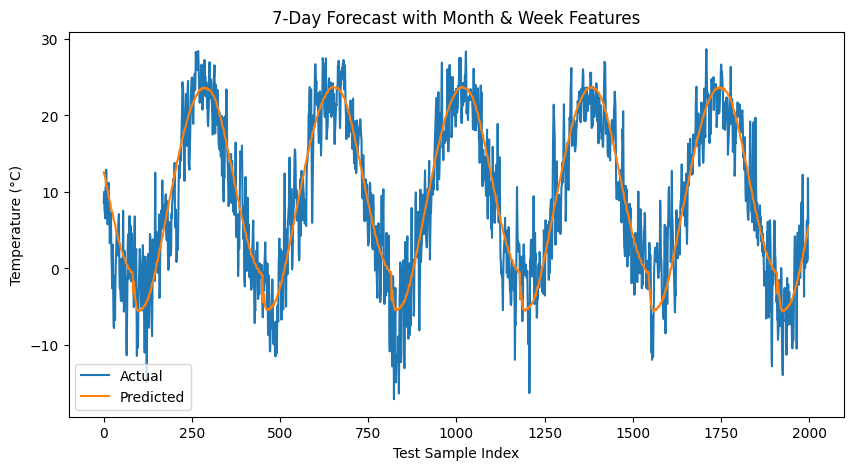

```python
y_pred = model.predict(X_test).flatten()

mae = mean_absolute_error(y_test, y_pred)
rmse = np.sqrt(mean_squared_error(y_test, y_pred))

print(f"7-Day Forecast with Enhanced Features - MAE: {mae:.2f}°C")
print(f"7-Day Forecast with Enhanced Features - RMSE: {rmse:.2f}°C")

plt.figure(figsize=(10,5))
plt.plot(y_test.values, label='Actual')
plt.plot(y_pred, label='Predicted')
plt.title("7-Day Forecast with Month & Week Features")
plt.xlabel("Test Sample Index")
plt.ylabel("Temperature (°C)")
plt.legend()
plt.show()
```

### 📈 Next Steps To Come:

- Add **recent weather context** (lag features like yesterday’s temp).
- Move toward **LSTM architecture** for sequence modeling.
- Optionally test **14-day** forecasts to see how performance changes with longer horizon

### Let's start to create on LSTM, and define our past window of days in our time series we want to use for prediction, and the future days for prediction

```python
N_PAST = 14
N_FUTURE = 7

# Feature columns to include (pick relevant ones — keep it small for now)
feature_cols = ['avg_temperature', 'precipitation', 'avg_relative_humidity', 'DayOfYear']

# Normalize (optional but helps LSTM)
from sklearn.preprocessing import MinMaxScaler

scaler = MinMaxScaler()
df_scaled = scaler.fit_transform(df[feature_cols])
df_scaled = pd.DataFrame(df_scaled, columns=feature_cols)

# Create sequences
X_lstm = []
y_lstm = []

for i in range(N_PAST, len(df_scaled) - N_FUTURE):
    X_lstm.append(df_scaled.iloc[i - N_PAST:i].values)
    y_lstm.append(df['avg_temperature'].iloc[i + N_FUTURE])  # raw value as target

#Train Test Split

X_lstm = np.array(X_lstm)
y_lstm = np.array(y_lstm)

print("X_lstm shape:", X_lstm.shape)
print("y_lstm shape:", y_lstm.shape)

split = int(0.8 * len(X_lstm)) #80/20 train test split
X_train, X_test = X_lstm[:split], X_lstm[split:]
y_train, y_test = y_lstm[:split], y_lstm[split:]
```

```
X_lstm shape: (9972, 14, 4)
y_lstm shape: (9972,)
```

### Implement LSTM w/ Keras API

```python
from tensorflow.keras.models import Sequential
from tensorflow.keras.layers import LSTM, Dense, Dropout

model = Sequential()
model.add(LSTM(64, activation='tanh', return_sequences=False, input_shape=(N_PAST, X_lstm.shape[2])))
model.add(Dropout(0.2))
model.add(Dense(1)) #1 Target Feature

model.compile(optimizer='adam', loss='mse', metrics=['mae'])

model.summary()

history = model.fit(
    X_train, y_train,
    epochs=175,
    batch_size=32,
    validation_split=0.1,
    verbose=1
)
```

```
Model: "sequential_2"
```

```
┏━━━━━━━━━━━━━━━━━━━━━━━━━━━━━━━━━┳━━━━━━━━━━━━━━━━━━━━━━━━┳━━━━━━━━━━━━━━━┓
┃ Layer (type)                    ┃ Output Shape           ┃       Param # ┃
┡━━━━━━━━━━━━━━━━━━━━━━━━━━━━━━━━━╇━━━━━━━━━━━━━━━━━━━━━━━━╇━━━━━━━━━━━━━━━┩
│ lstm (LSTM)                     │ (None, 64)             │        17,664 │
├─────────────────────────────────┼────────────────────────┼───────────────┤
│ dropout (Dropout)               │ (None, 64)             │             0 │
├─────────────────────────────────┼────────────────────────┼───────────────┤
│ dense_4 (Dense)                 │ (None, 1)              │            65 │
└─────────────────────────────────┴────────────────────────┴───────────────┘
```

```
 Total params: 17,729 (69.25 KB)
```

```
 Trainable params: 17,729 (69.25 KB)
```

```
 Non-trainable params: 0 (0.00 B)
```

```
225/225 ━━━━━━━━━━━━━━━━━━━━ 1s 3ms/step - loss: 121.6719 - mae: 9.0412 - val_loss: 31.1131 - val_mae: 4.3556
225/225 ━━━━━━━━━━━━━━━━━━━━ 1s 2ms/step - loss: 30.3151 - mae: 4.3724 - val_loss: 25.4740 - val_mae: 3.8735
225/225 ━━━━━━━━━━━━━━━━━━━━ 1s 2ms/step - loss: 25.8914 - mae: 4.0027 - val_loss: 27.5738 - val_mae: 4.1001
225/225 ━━━━━━━━━━━━━━━━━━━━ 1s 2ms/step - loss: 24.4500 - mae: 3.9267 - val_loss: 23.2732 - val_mae: 3.7522
225/225 ━━━━━━━━━━━━━━━━━━━━ 0s 2ms/step - loss: 22.9837 - mae: 3.8174 - val_loss: 24.1506 - val_mae: 3.8306
225/225 ━━━━━━━━━━━━━━━━━━━━ 1s 2ms/step - loss: 22.9866 - mae: 3.7723 - val_loss: 21.1415 - val_mae: 3.4870
225/225 ━━━━━━━━━━━━━━━━━━━━ 1s 2ms/step - loss: 21.5601 - mae: 3.6717 - val_loss: 21.2987 - val_mae: 3.5375
225/225 ━━━━━━━━━━━━━━━━━━━━ 1s 2ms/step - loss: 21.0251 - mae: 3.6487 - val_loss: 22.2312 - val_mae: 3.6649
225/225 ━━━━━━━━━━━━━━━━━━━━ 0s 2ms/step - loss: 21.2075 - mae: 3.6446 - val_loss: 21.5986 - val_mae: 3.5703
225/225 ━━━━━━━━━━━━━━━━━━━━ 0s 2ms/step - loss: 22.0216 - mae: 3.7410 - val_loss: 21.1205 - val_mae: 3.5449
225/225 ━━━━━━━━━━━━━━━━━━━━ 1s 2ms/step - loss: 21.2445 - mae: 3.6733 - val_loss: 21.7977 - val_mae: 3.5330
225/225 ━━━━━━━━━━━━━━━━━━━━ 1s 2ms/step - loss: 21.0186 - mae: 3.6442 - val_loss: 22.8812 - val_mae: 3.7905
225/225 ━━━━━━━━━━━━━━━━━━━━ 1s 2ms/step - loss: 20.6167 - mae: 3.6242 - val_loss: 21.8816 - val_mae: 3.5515
225/225 ━━━━━━━━━━━━━━━━━━━━ 0s 2ms/step - loss: 20.8118 - mae: 3.6208 - val_loss: 22.5412 - val_mae: 3.6758
225/225 ━━━━━━━━━━━━━━━━━━━━ 1s 2ms/step - loss: 20.6779 - mae: 3.6204 - val_loss: 22.3568 - val_mae: 3.5873
225/225 ━━━━━━━━━━━━━━━━━━━━ 1s 2ms/step - loss: 21.3112 - mae: 3.6553 - val_loss: 21.1829 - val_mae: 3.5563
225/225 ━━━━━━━━━━━━━━━━━━━━ 1s 2ms/step - loss: 21.4115 - mae: 3.6646 - val_loss: 22.4920 - val_mae: 3.5957
225/225 ━━━━━━━━━━━━━━━━━━━━ 1s 2ms/step - loss: 20.3780 - mae: 3.6023 - val_loss: 21.0627 - val_mae: 3.4891
225/225 ━━━━━━━━━━━━━━━━━━━━ 1s 2ms/step - loss: 20.5226 - mae: 3.6185 - val_loss: 22.5430 - val_mae: 3.6718
225/225 ━━━━━━━━━━━━━━━━━━━━ 1s 2ms/step - loss: 20.5176 - mae: 3.5829 - val_loss: 21.7661 - val_mae: 3.5316
225/225 ━━━━━━━━━━━━━━━━━━━━ 1s 2ms/step - loss: 21.0775 - mae: 3.6513 - val_loss: 21.9791 - val_mae: 3.5659
225/225 ━━━━━━━━━━━━━━━━━━━━ 1s 2ms/step - loss: 20.7236 - mae: 3.6263 - val_loss: 21.7160 - val_mae: 3.5662
225/225 ━━━━━━━━━━━━━━━━━━━━ 1s 2ms/step - loss: 20.7180 - mae: 3.6442 - val_loss: 20.9449 - val_mae: 3.4902
225/225 ━━━━━━━━━━━━━━━━━━━━ 1s 2ms/step - loss: 19.9524 - mae: 3.5507 - val_loss: 22.0533 - val_mae: 3.5952
225/225 ━━━━━━━━━━━━━━━━━━━━ 1s 2ms/step - loss: 20.1441 - mae: 3.5780 - val_loss: 20.8830 - val_mae: 3.4466
225/225 ━━━━━━━━━━━━━━━━━━━━ 1s 2ms/step - loss: 20.3927 - mae: 3.5923 - val_loss: 21.1713 - val_mae: 3.5222
225/225 ━━━━━━━━━━━━━━━━━━━━ 1s 2ms/step - loss: 20.3351 - mae: 3.5906 - val_loss: 21.1510 - val_mae: 3.5800
225/225 ━━━━━━━━━━━━━━━━━━━━ 1s 2ms/step - loss: 19.6239 - mae: 3.5171 - val_loss: 21.1342 - val_mae: 3.5608
225/225 ━━━━━━━━━━━━━━━━━━━━ 1s 2ms/step - loss: 20.6627 - mae: 3.6085 - val_loss: 21.3529 - val_mae: 3.4813
225/225 ━━━━━━━━━━━━━━━━━━━━ 1s 2ms/step - loss: 20.3737 - mae: 3.5940 - val_loss: 22.3888 - val_mae: 3.6642
225/225 ━━━━━━━━━━━━━━━━━━━━ 1s 2ms/step - loss: 20.4951 - mae: 3.5813 - val_loss: 20.7651 - val_mae: 3.4770
225/225 ━━━━━━━━━━━━━━━━━━━━ 1s 2ms/step - loss: 20.2473 - mae: 3.5833 - val_loss: 21.2808 - val_mae: 3.6052
225/225 ━━━━━━━━━━━━━━━━━━━━ 1s 2ms/step - loss: 19.9615 - mae: 3.5621 - val_loss: 22.1509 - val_mae: 3.5876
225/225 ━━━━━━━━━━━━━━━━━━━━ 1s 2ms/step - loss: 19.5160 - mae: 3.5267 - val_loss: 21.8396 - val_mae: 3.5516
225/225 ━━━━━━━━━━━━━━━━━━━━ 1s 2ms/step - loss: 20.0724 - mae: 3.5609 - val_loss: 21.7092 - val_mae: 3.5889
225/225 ━━━━━━━━━━━━━━━━━━━━ 1s 2ms/step - loss: 19.6983 - mae: 3.5264 - val_loss: 21.3261 - val_mae: 3.5767
225/225 ━━━━━━━━━━━━━━━━━━━━ 1s 2ms/step - loss: 19.9966 - mae: 3.5653 - val_loss: 21.7986 - val_mae: 3.5491
225/225 ━━━━━━━━━━━━━━━━━━━━ 1s 2ms/step - loss: 20.4098 - mae: 3.5716 - val_loss: 20.5804 - val_mae: 3.4646
225/225 ━━━━━━━━━━━━━━━━━━━━ 1s 2ms/step - loss: 19.8716 - mae: 3.5533 - val_loss: 21.1751 - val_mae: 3.5514
225/225 ━━━━━━━━━━━━━━━━━━━━ 1s 2ms/step - loss: 20.3791 - mae: 3.6069 - val_loss: 20.6137 - val_mae: 3.5020
```

[output cut: 120 more lines]

```
225/225 ━━━━━━━━━━━━━━━━━━━━ 1s 2ms/step - loss: 15.8156 - mae: 3.1800 - val_loss: 22.4230 - val_mae: 3.6652
225/225 ━━━━━━━━━━━━━━━━━━━━ 1s 2ms/step - loss: 15.5887 - mae: 3.1625 - val_loss: 23.2996 - val_mae: 3.6657
225/225 ━━━━━━━━━━━━━━━━━━━━ 1s 2ms/step - loss: 15.1398 - mae: 3.0859 - val_loss: 22.7770 - val_mae: 3.6944
225/225 ━━━━━━━━━━━━━━━━━━━━ 1s 2ms/step - loss: 15.4900 - mae: 3.1357 - val_loss: 21.2619 - val_mae: 3.5208
225/225 ━━━━━━━━━━━━━━━━━━━━ 1s 2ms/step - loss: 15.5738 - mae: 3.1303 - val_loss: 22.8952 - val_mae: 3.7077
225/225 ━━━━━━━━━━━━━━━━━━━━ 1s 2ms/step - loss: 16.0169 - mae: 3.1961 - val_loss: 23.3205 - val_mae: 3.7358
225/225 ━━━━━━━━━━━━━━━━━━━━ 1s 2ms/step - loss: 16.0324 - mae: 3.1912 - val_loss: 21.0827 - val_mae: 3.5160
225/225 ━━━━━━━━━━━━━━━━━━━━ 1s 2ms/step - loss: 15.3439 - mae: 3.1171 - val_loss: 23.0676 - val_mae: 3.6886
225/225 ━━━━━━━━━━━━━━━━━━━━ 1s 2ms/step - loss: 15.3039 - mae: 3.1258 - val_loss: 22.9344 - val_mae: 3.6973
225/225 ━━━━━━━━━━━━━━━━━━━━ 1s 2ms/step - loss: 15.0077 - mae: 3.0898 - val_loss: 23.3682 - val_mae: 3.7278
225/225 ━━━━━━━━━━━━━━━━━━━━ 1s 2ms/step - loss: 15.5261 - mae: 3.1351 - val_loss: 21.8972 - val_mae: 3.6073
225/225 ━━━━━━━━━━━━━━━━━━━━ 1s 2ms/step - loss: 14.7006 - mae: 3.0492 - val_loss: 22.9817 - val_mae: 3.7139
225/225 ━━━━━━━━━━━━━━━━━━━━ 1s 2ms/step - loss: 15.0499 - mae: 3.1120 - val_loss: 22.8505 - val_mae: 3.7023
225/225 ━━━━━━━━━━━━━━━━━━━━ 1s 2ms/step - loss: 14.7173 - mae: 3.0584 - val_loss: 22.5063 - val_mae: 3.6226
225/225 ━━━━━━━━━━━━━━━━━━━━ 1s 2ms/step - loss: 14.9166 - mae: 3.1030 - val_loss: 23.2093 - val_mae: 3.6860
```

### Evaluation

```
63/63 ━━━━━━━━━━━━━━━━━━━━ 0s 2ms/step
LSTM Model - 7-Day Ahead MAE: 3.67°C
LSTM Model - 7-Day Ahead RMSE: 4.68°C
```

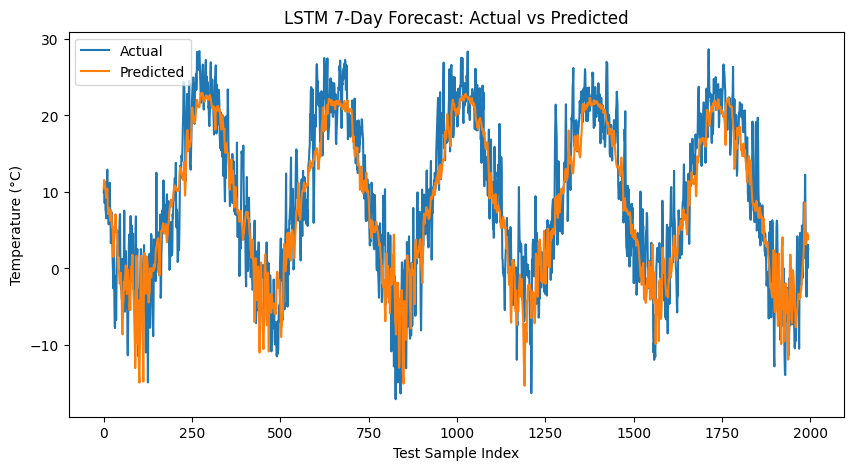

```python
y_pred = model.predict(X_test)

from sklearn.metrics import mean_absolute_error, mean_squared_error

mae = mean_absolute_error(y_test, y_pred)
rmse = np.sqrt(mean_squared_error(y_test, y_pred))

print(f"LSTM Model - 7-Day Ahead MAE: {mae:.2f}°C")
print(f"LSTM Model - 7-Day Ahead RMSE: {rmse:.2f}°C")
import matplotlib.pyplot as plt

plt.figure(figsize=(10,5))
plt.plot(y_test, label='Actual')
plt.plot(y_pred, label='Predicted')
plt.title("LSTM 7-Day Forecast: Actual vs Predicted")
plt.xlabel("Test Sample Index")
plt.ylabel("Temperature (°C)")
plt.legend()
plt.show()
```

### Commit Summary

- Created **sliding window sequences** using the past 14 days of weather
- Built a basic **LSTM model** using TensorFlow/Keras
- Trained on feature set: `avg_temperature`, `precipitation`, `avg_relative_humidity`, `DayOfYear`
- Normalized data using MinMaxScaler via **Scikit Learn**

### Next Commit:

- Try predicting a **range** of future days (e.g., full 7-day forecast)
- Stack LSTM layers or increase memory (more past days)

## Decrease Overfitting and Improve LSTM Model: Generate lagged features, Early Stopping, Scaled Feature Set w/ Lag

```python
#Create A Copy Of The DataFrame
df_model = df.copy()

#Generate Lag Values
for lag in range(1, 8):
    df_model[f'temp_lag_{lag}'] = df_model['avg_temperature'].shift(lag)
    df_model[f'precip_lag_{lag}'] = df_model['precipitation'].shift(lag)
    df_model[f'humid_lag_{lag}'] = df_model['avg_relative_humidity'].shift(lag)

# Drop rows with NaN values from lagging
df_model = df_model.dropna().reset_index(drop=True)

# Create Columns from Feature Set
feature_cols = [col for col in df_model.columns if 'lag' in col or col in [
    'avg_temperature', 'precipitation', 'avg_relative_humidity',
    'DayOfYear', 'sin_doy', 'cos_doy'
]]

#Scale the FeatureSet, and Create a DataFrame
scaler = MinMaxScaler()
scaled_features = scaler.fit_transform(df_model[feature_cols])
scaled_df = pd.DataFrame(scaled_features, columns=feature_cols)

#Repeat LSTM Steps to Populate Numpy Arrays
X_lstm = []
y_lstm = []

for i in range(N_PAST, len(scaled_df) - N_FUTURE):
    # Create sequence of past N_PAST days
    X_lstm.append(scaled_df.iloc[i - N_PAST:i].values)

    # Target is avg_temperature N_FUTURE days ahead (unscaled)
    y_lstm.append(df_model['avg_temperature'].iloc[i + N_FUTURE])

# Convert to arrays
X_lstm = np.array(X_lstm)
y_lstm = np.array(y_lstm)

print("X_lstm shape:", X_lstm.shape)  # (samples, 14, num_features)
print("y_lstm shape:", y_lstm.shape)  # (samples,)
```

```
X_lstm shape: (9965, 14, 27)
y_lstm shape: (9965,)
```

### Once Again Train Test Split 80/20

```python
split = int(0.8 * len(X_lstm))
X_train, X_test = X_lstm[:split], X_lstm[split:]
y_train, y_test = y_lstm[:split], y_lstm[split:]

print("Train shape:", X_train.shape)
print("Test shape:", X_test.shape)
```

```
Train shape: (7972, 14, 27)
Test shape: (1993, 14, 27)
```

### Instantiate And Compile New LSTM Model, now with Aggressive Dropout

```python
num_timesteps = X_train.shape[1]
num_features = X_train.shape[2]

#Implement LSTM with Aggressive Dropout to Avoid Overfitting, Like the Model In Our Previous Step Was
model = Sequential([
    LSTM(64, return_sequences=True, input_shape=(num_timesteps, num_features)),
    Dropout(0.3),
    LSTM(32),
    Dropout(0.3),
    Dense(1)
])

model.compile(optimizer='adam', loss='mse', metrics=['mae'])
model.summary()
```

```
Model: "sequential_3"
```

```
┏━━━━━━━━━━━━━━━━━━━━━━━━━━━━━━━━━┳━━━━━━━━━━━━━━━━━━━━━━━━┳━━━━━━━━━━━━━━━┓
┃ Layer (type)                    ┃ Output Shape           ┃       Param # ┃
┡━━━━━━━━━━━━━━━━━━━━━━━━━━━━━━━━━╇━━━━━━━━━━━━━━━━━━━━━━━━╇━━━━━━━━━━━━━━━┩
│ lstm_1 (LSTM)                   │ (None, 14, 64)         │        23,552 │
├─────────────────────────────────┼────────────────────────┼───────────────┤
│ dropout_1 (Dropout)             │ (None, 14, 64)         │             0 │
├─────────────────────────────────┼────────────────────────┼───────────────┤
│ lstm_2 (LSTM)                   │ (None, 32)             │        12,416 │
├─────────────────────────────────┼────────────────────────┼───────────────┤
│ dropout_2 (Dropout)             │ (None, 32)             │             0 │
├─────────────────────────────────┼────────────────────────┼───────────────┤
│ dense_5 (Dense)                 │ (None, 1)              │            33 │
└─────────────────────────────────┴────────────────────────┴───────────────┘
```

```
 Total params: 36,001 (140.63 KB)
```

```
 Trainable params: 36,001 (140.63 KB)
```

```
 Non-trainable params: 0 (0.00 B)
```

### Fit Model With Early Stopping

```python
from tensorflow.keras.callbacks import EarlyStopping

#Implement Early Stopping To Decrease Overfitting
early_stop = EarlyStopping(monitor='val_loss', patience=5, restore_best_weights=True)
history = model.fit(
    X_train, y_train,
    validation_split=0.1,
    epochs=100,
    batch_size=32,
    callbacks=[early_stop],
    verbose=1
)
```

```
225/225 ━━━━━━━━━━━━━━━━━━━━ 2s 4ms/step - loss: 108.8271 - mae: 8.5206 - val_loss: 40.6013 - val_mae: 5.1772
225/225 ━━━━━━━━━━━━━━━━━━━━ 1s 4ms/step - loss: 36.1306 - mae: 4.8903 - val_loss: 26.0316 - val_mae: 4.1529
225/225 ━━━━━━━━━━━━━━━━━━━━ 1s 4ms/step - loss: 25.3405 - mae: 4.0474 - val_loss: 25.7099 - val_mae: 3.9786
225/225 ━━━━━━━━━━━━━━━━━━━━ 1s 4ms/step - loss: 23.5047 - mae: 3.8870 - val_loss: 26.3552 - val_mae: 3.9785
225/225 ━━━━━━━━━━━━━━━━━━━━ 1s 4ms/step - loss: 23.7359 - mae: 3.9041 - val_loss: 20.8962 - val_mae: 3.4970
225/225 ━━━━━━━━━━━━━━━━━━━━ 1s 4ms/step - loss: 22.2359 - mae: 3.7567 - val_loss: 22.8993 - val_mae: 3.7803
225/225 ━━━━━━━━━━━━━━━━━━━━ 1s 4ms/step - loss: 22.0141 - mae: 3.7530 - val_loss: 20.7146 - val_mae: 3.4928
225/225 ━━━━━━━━━━━━━━━━━━━━ 1s 4ms/step - loss: 21.9626 - mae: 3.7370 - val_loss: 21.1835 - val_mae: 3.6216
225/225 ━━━━━━━━━━━━━━━━━━━━ 1s 4ms/step - loss: 21.9398 - mae: 3.7449 - val_loss: 21.9902 - val_mae: 3.6101
225/225 ━━━━━━━━━━━━━━━━━━━━ 1s 4ms/step - loss: 21.6373 - mae: 3.7203 - val_loss: 20.8028 - val_mae: 3.5796
225/225 ━━━━━━━━━━━━━━━━━━━━ 1s 4ms/step - loss: 21.8181 - mae: 3.7255 - val_loss: 21.5906 - val_mae: 3.5548
225/225 ━━━━━━━━━━━━━━━━━━━━ 1s 4ms/step - loss: 21.4617 - mae: 3.7026 - val_loss: 20.3486 - val_mae: 3.4692
225/225 ━━━━━━━━━━━━━━━━━━━━ 1s 4ms/step - loss: 21.4858 - mae: 3.7182 - val_loss: 20.7675 - val_mae: 3.4717
225/225 ━━━━━━━━━━━━━━━━━━━━ 1s 4ms/step - loss: 21.8368 - mae: 3.7363 - val_loss: 21.1123 - val_mae: 3.5679
225/225 ━━━━━━━━━━━━━━━━━━━━ 1s 4ms/step - loss: 21.8572 - mae: 3.7275 - val_loss: 20.6784 - val_mae: 3.4975
225/225 ━━━━━━━━━━━━━━━━━━━━ 1s 4ms/step - loss: 21.3856 - mae: 3.7193 - val_loss: 21.3464 - val_mae: 3.5318
225/225 ━━━━━━━━━━━━━━━━━━━━ 1s 4ms/step - loss: 21.4497 - mae: 3.7088 - val_loss: 20.7954 - val_mae: 3.4745
```

### Evaluate

```python
#Evaluate Metrics

y_pred = model.predict(X_test).flatten()

mae = mean_absolute_error(y_test, y_pred)
rmse = np.sqrt(mean_squared_error(y_test, y_pred))

print(f"Improved LSTM - 7-Day Ahead MAE: {mae:.2f}°C")
print(f"Improved LSTM - 7-Day Ahead RMSE: {rmse:.2f}°C")
```

```
63/63 ━━━━━━━━━━━━━━━━━━━━ 0s 3ms/step
Improved LSTM - 7-Day Ahead MAE: 3.50°C
Improved LSTM - 7-Day Ahead RMSE: 4.44°C
```

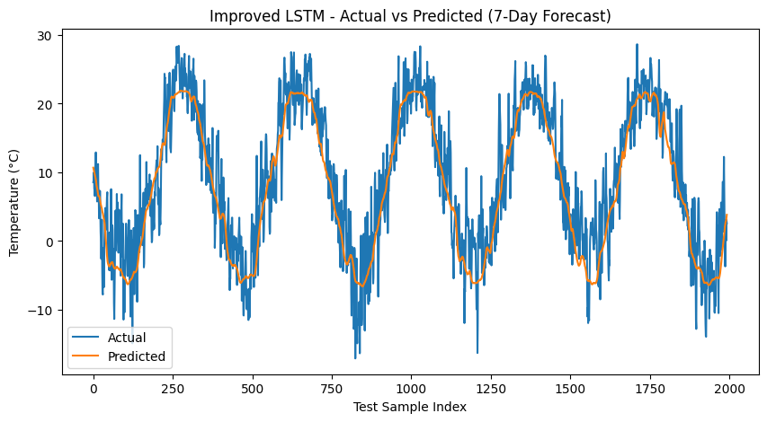

```python
plt.figure(figsize=(10,5))
plt.plot(y_test, label='Actual')
plt.plot(y_pred, label='Predicted')
plt.title("Improved LSTM - Actual vs Predicted (7-Day Forecast)")
plt.xlabel("Test Sample Index")
plt.ylabel("Temperature (°C)")
plt.legend()
plt.show()
```

## Commit Summary: Enhancing LSTM Accuracy with Lag Features and a Deeper Model

### Let's Finalize Our LSTM Model and Take Some Key Metrics in Terms of Improvement

### As a User I want to:

- Use Past Data and Trends to Predict Weekly Weather
- Weather in the Next Month
- Weather any day in the upcoming year using the general trends

### Let's Create Multiple Model Designed For Each of Our Objectives

```python
"""
Function to create an LSTM Dataset using our Scaled DataFrame
Forecast_Days_Ahead: The amount of days we want to predict ahead
Past_Days: Days we use to make our prediction
"""
def create_lstm_dataset(forecast_days_ahead, past_days=14):
    X, y = [], []
    for i in range(past_days, len(scaled_df) - forecast_days_ahead):
        X.append(scaled_df.iloc[i-past_days:i].values)
        y.append(df["avg_temperature"].iloc[i+forecast_days_ahead])

    return np.array(X), np.array(y)

# Generate all 3 datasets
X_7, y_7 = create_lstm_dataset(7)
X_14, y_14 = create_lstm_dataset(14)
X_30, y_30 = create_lstm_dataset(30)

def split(X, y):
    i = int(0.8 * len(X))
    return X[:i], X[i:], y[:i], y[i:]

X7_train, X7_test, y7_train, y7_test = split(X_7, y_7)
X14_train, X14_test, y14_train, y14_test = split(X_14, y_14)
X30_train, X30_test, y30_train, y30_test = split(X_30, y_30)
```

### Let's Encapsulate Our LSTM Logic, Since We're Creating Multiple Models Now

```python
from tensorflow.keras.layers import Bidirectional
def train_lstm(X_train, y_train, X_test, y_test, name="model"):
    #Initialize LSTM
    model = Sequential([
        Bidirectional(LSTM(64, return_sequences=True), input_shape=(X_train.shape[1], X_train.shape[2])),
        Dropout(0.2),
        LSTM(32),
        Dropout(0.2),
        Dense(1)
    ])

    #Compile & Train Model

    model.compile(optimizer='adam', loss='mse', metrics=['mae'])
    early_stop = EarlyStopping(monitor='val_loss', patience=5 , restore_best_weights=True)

    history = model.fit(

        X_train, y_train,
        validation_split=0.1,
        epochs=100,
        batch_size=32,
        callbacks=[early_stop],
        verbose=1
    )

    #Predict

    y_pred = model.predict(X_test).flatten()

    mae = mean_absolute_error(y_test, y_pred)
    rmse = np.sqrt(mean_squared_error(y_test, y_pred))

    print(f"{name} MAE: {mae:.2f}°C | RMSE: {rmse:.2f}°C")

    model.save(f"{name}.h5")
    return model, y_test, y_pred, mae, rmse
```

### Train All Models

```python
#Call Our Training Functions For Respective Models
model_7, y7_true, y7_pred, mae7, rmse7 = train_lstm(X7_train, y7_train, X7_test, y7_test, name="lstm_7day")
model_14, y14_true, y14_pred, mae14, rmse14 = train_lstm(X14_train, y14_train, X14_test, y14_test, name="lstm_14day")
model_30, y30_true, y30_pred, mae30, rmse30 = train_lstm(X30_train, y30_train, X30_test, y30_test, name="lstm_30day")
```

```
225/225 ━━━━━━━━━━━━━━━━━━━━ 3s 5ms/step - loss: 101.8912 - mae: 8.1743 - val_loss: 37.2685 - val_mae: 4.9368
225/225 ━━━━━━━━━━━━━━━━━━━━ 1s 4ms/step - loss: 31.2598 - mae: 4.5234 - val_loss: 23.6629 - val_mae: 3.8632
225/225 ━━━━━━━━━━━━━━━━━━━━ 1s 4ms/step - loss: 20.1206 - mae: 3.5798 - val_loss: 16.9185 - val_mae: 3.2830
225/225 ━━━━━━━━━━━━━━━━━━━━ 1s 4ms/step - loss: 16.8864 - mae: 3.2766 - val_loss: 14.7669 - val_mae: 3.0583
225/225 ━━━━━━━━━━━━━━━━━━━━ 1s 4ms/step - loss: 14.9160 - mae: 3.0556 - val_loss: 13.6240 - val_mae: 2.8776
225/225 ━━━━━━━━━━━━━━━━━━━━ 1s 4ms/step - loss: 14.9655 - mae: 3.0323 - val_loss: 12.7484 - val_mae: 2.8080
225/225 ━━━━━━━━━━━━━━━━━━━━ 1s 4ms/step - loss: 13.6819 - mae: 2.9401 - val_loss: 11.8862 - val_mae: 2.6849
225/225 ━━━━━━━━━━━━━━━━━━━━ 1s 4ms/step - loss: 13.5679 - mae: 2.9062 - val_loss: 13.4309 - val_mae: 2.8434
225/225 ━━━━━━━━━━━━━━━━━━━━ 1s 4ms/step - loss: 13.0971 - mae: 2.8422 - val_loss: 11.1960 - val_mae: 2.6349
225/225 ━━━━━━━━━━━━━━━━━━━━ 1s 4ms/step - loss: 12.7404 - mae: 2.8262 - val_loss: 11.2338 - val_mae: 2.5732
225/225 ━━━━━━━━━━━━━━━━━━━━ 1s 4ms/step - loss: 11.7397 - mae: 2.6963 - val_loss: 11.0201 - val_mae: 2.6068
225/225 ━━━━━━━━━━━━━━━━━━━━ 1s 4ms/step - loss: 12.1223 - mae: 2.7562 - val_loss: 11.3214 - val_mae: 2.5863
225/225 ━━━━━━━━━━━━━━━━━━━━ 1s 4ms/step - loss: 12.8408 - mae: 2.8300 - val_loss: 10.6980 - val_mae: 2.5569
225/225 ━━━━━━━━━━━━━━━━━━━━ 1s 4ms/step - loss: 11.8101 - mae: 2.7081 - val_loss: 10.0384 - val_mae: 2.4690
225/225 ━━━━━━━━━━━━━━━━━━━━ 1s 4ms/step - loss: 11.8615 - mae: 2.7037 - val_loss: 11.5517 - val_mae: 2.7014
225/225 ━━━━━━━━━━━━━━━━━━━━ 1s 4ms/step - loss: 11.7630 - mae: 2.6914 - val_loss: 9.6172 - val_mae: 2.4023
225/225 ━━━━━━━━━━━━━━━━━━━━ 1s 4ms/step - loss: 11.5613 - mae: 2.6741 - val_loss: 10.1711 - val_mae: 2.4745
225/225 ━━━━━━━━━━━━━━━━━━━━ 1s 4ms/step - loss: 11.5527 - mae: 2.6671 - val_loss: 10.9320 - val_mae: 2.6147
225/225 ━━━━━━━━━━━━━━━━━━━━ 1s 4ms/step - loss: 11.5972 - mae: 2.6786 - val_loss: 9.3976 - val_mae: 2.3512
225/225 ━━━━━━━━━━━━━━━━━━━━ 1s 4ms/step - loss: 11.3874 - mae: 2.6597 - val_loss: 9.8011 - val_mae: 2.4098
225/225 ━━━━━━━━━━━━━━━━━━━━ 1s 4ms/step - loss: 11.4283 - mae: 2.6526 - val_loss: 9.9134 - val_mae: 2.4321
225/225 ━━━━━━━━━━━━━━━━━━━━ 1s 4ms/step - loss: 10.9887 - mae: 2.5919 - val_loss: 9.6464 - val_mae: 2.4208
225/225 ━━━━━━━━━━━━━━━━━━━━ 1s 4ms/step - loss: 11.6752 - mae: 2.6749 - val_loss: 9.9489 - val_mae: 2.4439
225/225 ━━━━━━━━━━━━━━━━━━━━ 1s 4ms/step - loss: 11.6273 - mae: 2.6737 - val_loss: 9.2546 - val_mae: 2.3525
225/225 ━━━━━━━━━━━━━━━━━━━━ 1s 4ms/step - loss: 10.9002 - mae: 2.5830 - val_loss: 9.3985 - val_mae: 2.3602
225/225 ━━━━━━━━━━━━━━━━━━━━ 1s 4ms/step - loss: 11.1496 - mae: 2.6259 - val_loss: 9.2613 - val_mae: 2.3415
225/225 ━━━━━━━━━━━━━━━━━━━━ 1s 4ms/step - loss: 10.9694 - mae: 2.5813 - val_loss: 9.4242 - val_mae: 2.3893
225/225 ━━━━━━━━━━━━━━━━━━━━ 1s 4ms/step - loss: 10.9833 - mae: 2.5775 - val_loss: 11.7481 - val_mae: 2.6885
225/225 ━━━━━━━━━━━━━━━━━━━━ 1s 4ms/step - loss: 11.1298 - mae: 2.6172 - val_loss: 9.6772 - val_mae: 2.4077
63/63 ━━━━━━━━━━━━━━━━━━━━ 0s 4ms/step
```

```
WARNING:absl:You are saving your model as an HDF5 file via `model.save()` or `keras.saving.save_model(model)`. This file format is considered legacy. We recommend using instead the native Keras format, e.g. `model.save('my_model.keras')` or `keras.saving.save_model(model, 'my_model.keras')`.
```

```
lstm_7day MAE: 2.32°C | RMSE: 2.97°C
```

```
225/225 ━━━━━━━━━━━━━━━━━━━━ 3s 5ms/step - loss: 105.3915 - mae: 8.2768 - val_loss: 45.7945 - val_mae: 5.6052
225/225 ━━━━━━━━━━━━━━━━━━━━ 1s 4ms/step - loss: 35.5436 - mae: 4.8421 - val_loss: 28.0229 - val_mae: 4.2333
225/225 ━━━━━━━━━━━━━━━━━━━━ 1s 4ms/step - loss: 26.2055 - mae: 4.1118 - val_loss: 28.2840 - val_mae: 4.2700
225/225 ━━━━━━━━━━━━━━━━━━━━ 1s 4ms/step - loss: 23.1724 - mae: 3.8144 - val_loss: 22.3810 - val_mae: 3.6626
225/225 ━━━━━━━━━━━━━━━━━━━━ 1s 4ms/step - loss: 21.5693 - mae: 3.7035 - val_loss: 20.6351 - val_mae: 3.5459
225/225 ━━━━━━━━━━━━━━━━━━━━ 1s 4ms/step - loss: 21.2538 - mae: 3.6719 - val_loss: 22.8170 - val_mae: 3.7624
225/225 ━━━━━━━━━━━━━━━━━━━━ 1s 4ms/step - loss: 21.0635 - mae: 3.6435 - val_loss: 20.9112 - val_mae: 3.5574
225/225 ━━━━━━━━━━━━━━━━━━━━ 1s 4ms/step - loss: 20.7478 - mae: 3.6096 - val_loss: 21.4231 - val_mae: 3.6099
225/225 ━━━━━━━━━━━━━━━━━━━━ 1s 4ms/step - loss: 20.9067 - mae: 3.6335 - val_loss: 21.0377 - val_mae: 3.5878
225/225 ━━━━━━━━━━━━━━━━━━━━ 1s 4ms/step - loss: 21.4093 - mae: 3.6876 - val_loss: 20.0670 - val_mae: 3.5043
225/225 ━━━━━━━━━━━━━━━━━━━━ 1s 4ms/step - loss: 20.7800 - mae: 3.6239 - val_loss: 21.0112 - val_mae: 3.5012
225/225 ━━━━━━━━━━━━━━━━━━━━ 1s 4ms/step - loss: 21.2363 - mae: 3.6678 - val_loss: 20.8612 - val_mae: 3.4813
225/225 ━━━━━━━━━━━━━━━━━━━━ 1s 4ms/step - loss: 20.3913 - mae: 3.5914 - val_loss: 20.2903 - val_mae: 3.4952
225/225 ━━━━━━━━━━━━━━━━━━━━ 1s 4ms/step - loss: 20.7212 - mae: 3.6332 - val_loss: 19.6227 - val_mae: 3.4218
225/225 ━━━━━━━━━━━━━━━━━━━━ 1s 4ms/step - loss: 20.2050 - mae: 3.5449 - val_loss: 21.4489 - val_mae: 3.5794
225/225 ━━━━━━━━━━━━━━━━━━━━ 1s 4ms/step - loss: 20.4114 - mae: 3.5907 - val_loss: 20.3467 - val_mae: 3.4977
225/225 ━━━━━━━━━━━━━━━━━━━━ 1s 4ms/step - loss: 20.7988 - mae: 3.6396 - val_loss: 21.3568 - val_mae: 3.5308
225/225 ━━━━━━━━━━━━━━━━━━━━ 1s 4ms/step - loss: 20.4917 - mae: 3.6211 - val_loss: 20.1964 - val_mae: 3.4864
225/225 ━━━━━━━━━━━━━━━━━━━━ 1s 4ms/step - loss: 20.7300 - mae: 3.6374 - val_loss: 21.8991 - val_mae: 3.6099
63/63 ━━━━━━━━━━━━━━━━━━━━ 0s 4ms/step
```

```
WARNING:absl:You are saving your model as an HDF5 file via `model.save()` or `keras.saving.save_model(model)`. This file format is considered legacy. We recommend using instead the native Keras format, e.g. `model.save('my_model.keras')` or `keras.saving.save_model(model, 'my_model.keras')`.
```

```
lstm_14day MAE: 3.51°C | RMSE: 4.45°C
```

```
224/224 ━━━━━━━━━━━━━━━━━━━━ 3s 5ms/step - loss: 110.8701 - mae: 8.5521 - val_loss: 45.2406 - val_mae: 5.5751
224/224 ━━━━━━━━━━━━━━━━━━━━ 1s 4ms/step - loss: 35.9556 - mae: 4.9131 - val_loss: 28.2345 - val_mae: 4.2794
224/224 ━━━━━━━━━━━━━━━━━━━━ 1s 4ms/step - loss: 26.0850 - mae: 4.1036 - val_loss: 22.8159 - val_mae: 3.7864
224/224 ━━━━━━━━━━━━━━━━━━━━ 1s 4ms/step - loss: 23.2905 - mae: 3.8366 - val_loss: 23.9345 - val_mae: 3.8145
224/224 ━━━━━━━━━━━━━━━━━━━━ 1s 4ms/step - loss: 21.1737 - mae: 3.6391 - val_loss: 21.0177 - val_mae: 3.6431
224/224 ━━━━━━━━━━━━━━━━━━━━ 1s 4ms/step - loss: 22.0305 - mae: 3.7183 - val_loss: 21.1219 - val_mae: 3.5855
224/224 ━━━━━━━━━━━━━━━━━━━━ 1s 4ms/step - loss: 20.9838 - mae: 3.6464 - val_loss: 21.2156 - val_mae: 3.5605
224/224 ━━━━━━━━━━━━━━━━━━━━ 1s 4ms/step - loss: 22.3073 - mae: 3.7627 - val_loss: 26.7247 - val_mae: 4.0206
224/224 ━━━━━━━━━━━━━━━━━━━━ 1s 4ms/step - loss: 21.0234 - mae: 3.6669 - val_loss: 20.5849 - val_mae: 3.5655
224/224 ━━━━━━━━━━━━━━━━━━━━ 1s 4ms/step - loss: 20.7111 - mae: 3.5973 - val_loss: 21.2058 - val_mae: 3.5612
224/224 ━━━━━━━━━━━━━━━━━━━━ 1s 4ms/step - loss: 20.0662 - mae: 3.5636 - val_loss: 19.6151 - val_mae: 3.4635
224/224 ━━━━━━━━━━━━━━━━━━━━ 1s 4ms/step - loss: 20.5583 - mae: 3.6124 - val_loss: 20.7392 - val_mae: 3.5156
224/224 ━━━━━━━━━━━━━━━━━━━━ 1s 4ms/step - loss: 21.1157 - mae: 3.6361 - val_loss: 21.5023 - val_mae: 3.6379
224/224 ━━━━━━━━━━━━━━━━━━━━ 1s 4ms/step - loss: 20.8073 - mae: 3.6105 - val_loss: 20.9710 - val_mae: 3.5354
224/224 ━━━━━━━━━━━━━━━━━━━━ 1s 4ms/step - loss: 20.8018 - mae: 3.6228 - val_loss: 20.6737 - val_mae: 3.5350
224/224 ━━━━━━━━━━━━━━━━━━━━ 1s 4ms/step - loss: 21.3829 - mae: 3.6687 - val_loss: 20.5769 - val_mae: 3.4858
63/63 ━━━━━━━━━━━━━━━━━━━━ 0s 4ms/step
```

```
WARNING:absl:You are saving your model as an HDF5 file via `model.save()` or `keras.saving.save_model(model)`. This file format is considered legacy. We recommend using instead the native Keras format, e.g. `model.save('my_model.keras')` or `keras.saving.save_model(model, 'my_model.keras')`.
```

```
lstm_30day MAE: 3.46°C | RMSE: 4.38°C
```

### Measure Accuracy

```python
def accuracy(mae, temp_range=40):  # Approximate Toronto range
    return round((1 - mae / temp_range) * 100, 2)

acc7 = accuracy(mae7)
acc14 = accuracy(mae14)
acc30 = accuracy(mae30)
```

### Evaluation Table

```python
import pandas as pd

summary = pd.DataFrame({
    "Forecast Days": [7, 14, 30],
    "MAE (°C)": [mae7, mae14, mae30],
    "RMSE (°C)": [rmse7, rmse14, rmse30],
    "Accuracy %": [acc7, acc14, acc30],
    "Confidence": ["High", "Medium", "Low"]
})
summary
```

|  | Forecast Days | MAE (°C) | RMSE (°C) | Accuracy % | Confidence |
| --- | --- | --- | --- | --- | --- |
| 0 | 7 | 2.319282 | 2.971684 | 94.20 | High |
| 1 | 14 | 3.507368 | 4.453721 | 91.23 | Medium |
| 2 | 30 | 3.462877 | 4.376404 | 91.34 | Low |

```python
from tensorflow.keras.models import Sequential
from tensorflow.keras.layers import Dense

X_seasonal = df[['DayOfYear', 'sin_doy', 'cos_doy']]
y_seasonal = df['avg_temperature']

scaler_seasonal = MinMaxScaler()
X_seasonal_scaled = scaler_seasonal.fit_transform(X_seasonal)

X_s_train, X_s_test, y_s_train, y_s_test = split(X_seasonal_scaled, y_seasonal)

model_seasonal = Sequential([
    Dense(64, activation='relu', input_shape=(X_seasonal_scaled.shape[1],)),
    Dense(32, activation='relu'),
    Dense(1)
])
model_seasonal.compile(optimizer='adam', loss='mse', metrics=['mae'])

model_seasonal.fit(
    X_s_train, y_s_train,
    validation_split=0.1,
    epochs=100,
    callbacks=[EarlyStopping(patience=5, restore_best_weights=True)],
    verbose=1
)

# Save seasonal model
model_seasonal.save("seasonal_anyday_model.h5")
```

```
225/225 ━━━━━━━━━━━━━━━━━━━━ 1s 1ms/step - loss: 158.0337 - mae: 10.3932 - val_loss: 43.7152 - val_mae: 5.4085
225/225 ━━━━━━━━━━━━━━━━━━━━ 0s 780us/step - loss: 27.6593 - mae: 4.1716 - val_loss: 20.9469 - val_mae: 3.4658
225/225 ━━━━━━━━━━━━━━━━━━━━ 0s 788us/step - loss: 20.9977 - mae: 3.6109 - val_loss: 20.0787 - val_mae: 3.4155
225/225 ━━━━━━━━━━━━━━━━━━━━ 0s 794us/step - loss: 19.9751 - mae: 3.5287 - val_loss: 19.7739 - val_mae: 3.3775
225/225 ━━━━━━━━━━━━━━━━━━━━ 0s 772us/step - loss: 20.0666 - mae: 3.5452 - val_loss: 19.6615 - val_mae: 3.3753
225/225 ━━━━━━━━━━━━━━━━━━━━ 0s 788us/step - loss: 20.0510 - mae: 3.5475 - val_loss: 19.3868 - val_mae: 3.3738
225/225 ━━━━━━━━━━━━━━━━━━━━ 0s 771us/step - loss: 18.9870 - mae: 3.4390 - val_loss: 19.2777 - val_mae: 3.3324
225/225 ━━━━━━━━━━━━━━━━━━━━ 0s 770us/step - loss: 19.8124 - mae: 3.5169 - val_loss: 19.2222 - val_mae: 3.3385
225/225 ━━━━━━━━━━━━━━━━━━━━ 0s 783us/step - loss: 19.7138 - mae: 3.4867 - val_loss: 19.3977 - val_mae: 3.3617
225/225 ━━━━━━━━━━━━━━━━━━━━ 0s 763us/step - loss: 19.3867 - mae: 3.4870 - val_loss: 19.1333 - val_mae: 3.3279
225/225 ━━━━━━━━━━━━━━━━━━━━ 0s 770us/step - loss: 19.8248 - mae: 3.5186 - val_loss: 19.6517 - val_mae: 3.4103
225/225 ━━━━━━━━━━━━━━━━━━━━ 0s 783us/step - loss: 19.7816 - mae: 3.5372 - val_loss: 19.0387 - val_mae: 3.3455
225/225 ━━━━━━━━━━━━━━━━━━━━ 0s 793us/step - loss: 19.3737 - mae: 3.4811 - val_loss: 19.1637 - val_mae: 3.3417
225/225 ━━━━━━━━━━━━━━━━━━━━ 0s 778us/step - loss: 19.2084 - mae: 3.4645 - val_loss: 19.1292 - val_mae: 3.3293
225/225 ━━━━━━━━━━━━━━━━━━━━ 0s 816us/step - loss: 19.7008 - mae: 3.4931 - val_loss: 19.4743 - val_mae: 3.3722
225/225 ━━━━━━━━━━━━━━━━━━━━ 0s 789us/step - loss: 19.5624 - mae: 3.4917 - val_loss: 19.3383 - val_mae: 3.3543
225/225 ━━━━━━━━━━━━━━━━━━━━ 0s 771us/step - loss: 19.4227 - mae: 3.4957 - val_loss: 19.6149 - val_mae: 3.3992
```

```
WARNING:absl:You are saving your model as an HDF5 file via `model.save()` or `keras.saving.save_model(model)`. This file format is considered legacy. We recommend using instead the native Keras format, e.g. `model.save('my_model.keras')` or `keras.saving.save_model(model, 'my_model.keras')`.
```

```python
def estimate_confidence(days_ahead: int, model_used: str) -> float:
    """
    Estimate forecast confidence based on days ahead and model used.
    Confidence scores are normalized to [0, 1].

    Args:
        days_ahead (int): Number of days into the future being predicted
        model_used (str): One of ['lstm_7day', 'lstm_14day', 'lstm_30day', 'seasonal_anyday']

    Returns:
        float: confidence score between 0 and 1
    """

    base_confidence = {
        'lstm_7day': 0.9,
        'lstm_14day': 0.75,
        'lstm_30day': 0.6,
        'seasonal_anyday': 0.5
    }

    # Start from base
    confidence = base_confidence.get(model_used, 0.5)

    # Decrease confidence if user forecasts too far using a short-horizon model
    if model_used == 'lstm_7day' and days_ahead > 7:
        confidence -= 0.15
    elif model_used == 'lstm_14day' and days_ahead > 14:
        confidence -= 0.1
    elif model_used == 'lstm_30day' and days_ahead > 30:
        confidence -= 0.1

    # Apply soft lower bound
    confidence = max(0.2, confidence)

    return round(confidence, 2)
```

```python
print(estimate_confidence(5, 'lstm_7day'))    # ✅ 0.9
print(estimate_confidence(9, 'lstm_7day'))       # 🔻 0.75
print(estimate_confidence(20, 'lstm_14day'))     # 🔻 0.65
print(estimate_confidence(100, 'seasonal_anyday'))  # ✅ 0.5
print(estimate_confidence(300, 'lstm_30day'))    # 🔻 0.5
```

```
0.9
0.75
0.65
0.5
0.5
```

```python
def calculate_improvement(new_mae, old_mae):
    return round((old_mae - new_mae) / old_mae * 100, 2)

baseline_mae = 4.55  # From Day 1 baseline
improvement_7 = calculate_improvement(mae7, baseline_mae)
improvement_14 = calculate_improvement(mae14, baseline_mae)
improvement_30 = calculate_improvement(mae30, baseline_mae)

print(f"7-Day MAE Improvement: {improvement_7}%")
print(f"14-Day MAE Improvement: {improvement_14}%")
print(f"30-Day MAE Improvement: {improvement_30}%")
```

```
7-Day MAE Improvement: 49.03%
14-Day MAE Improvement: 22.91%
30-Day MAE Improvement: 23.89%
```

### Example Confidence Outputs:

- 5-day forecast using `lstm_7day` → 0.9 (High)
- 9-day forecast using `lstm_7day` → 0.75 (Medium)
- 100-day forecast using seasonal model → 0.5 (Low)

### Accuracy Improvement Summary (vs. Day 1 Baseline)

- **7-Day Model**: +49.03% improvement in MAE
- **14-Day Model**: +22.91% improvement
- **30-Day Model**: +23.89% improvement

# New Cell: Retrain Models and Export Scalers for API Prediction Script

## After finding unexpected and unrealistic predictions from our backend prediction script, we're gonna train each model with the exact same scaler, and export them to be used for our prediction script

```python
from sklearn.preprocessing import MinMaxScaler
import joblib

# Extract seasonal features and temperature target
X_seasonal = df[["DayOfYear", "sin_doy", "cos_doy"]]
y_target = df[["avg_temperature"]]

# Fit input and output scalers
input_scaler = MinMaxScaler().fit(X_seasonal)
target_scaler = MinMaxScaler().fit(y_target)

# Save to disk
joblib.dump(input_scaler, "./seasonal_scaler.pkl")
joblib.dump(target_scaler, "./target_scaler.pkl")

print("✅ Scalers saved: seasonal_scaler.pkl and target_scaler.pkl")
```

```
✅ Scalers saved: seasonal_scaler.pkl and target_scaler.pkl
```

```python
from sklearn.preprocessing import MinMaxScaler
import joblib
from tensorflow.keras.models import Sequential
from tensorflow.keras.layers import Dense
from tensorflow.keras.callbacks import EarlyStopping

# Prepare features
X_seasonal = df[['DayOfYear', 'sin_doy', 'cos_doy']]
y_seasonal = df[['avg_temperature']]

# Scale inputs and outputs
input_scaler = MinMaxScaler().fit(X_seasonal)
target_scaler = MinMaxScaler().fit(y_seasonal)

# Save the scalers
joblib.dump(input_scaler, "./seasonal_scaler.pkl")
joblib.dump(target_scaler, "./target_scaler.pkl")

# Transform inputs and outputs
X_seasonal_scaled = input_scaler.transform(X_seasonal)
y_seasonal_scaled = target_scaler.transform(y_seasonal)

# Split data
X_s_train, X_s_test, y_s_train, y_s_test = split(X_seasonal_scaled, y_seasonal_scaled)

# Build and train model
model_seasonal = Sequential([
    Dense(64, activation='relu', input_shape=(X_seasonal_scaled.shape[1],)),
    Dense(32, activation='relu'),
    Dense(1)
])
model_seasonal.compile(optimizer='adam', loss='mse', metrics=['mae'])

model_seasonal.fit(
    X_s_train, y_s_train,
    validation_split=0.1,
    epochs=100,
    callbacks=[EarlyStopping(patience=5, restore_best_weights=True)],
    verbose=1
)

# Save trained model
model_seasonal.save("./seasonal_anyday_model.h5")
print("✅ Retrained seasonal_anyday_model.h5 using scaled y + saved scalers.")
```

```
225/225 ━━━━━━━━━━━━━━━━━━━━ 1s 1ms/step - loss: 0.1132 - mae: 0.2512 - val_loss: 0.0071 - val_mae: 0.0631
225/225 ━━━━━━━━━━━━━━━━━━━━ 0s 769us/step - loss: 0.0069 - mae: 0.0654 - val_loss: 0.0069 - val_mae: 0.0639
225/225 ━━━━━━━━━━━━━━━━━━━━ 0s 792us/step - loss: 0.0068 - mae: 0.0650 - val_loss: 0.0072 - val_mae: 0.0655
225/225 ━━━━━━━━━━━━━━━━━━━━ 0s 778us/step - loss: 0.0069 - mae: 0.0658 - val_loss: 0.0069 - val_mae: 0.0631
225/225 ━━━━━━━━━━━━━━━━━━━━ 0s 775us/step - loss: 0.0066 - mae: 0.0642 - val_loss: 0.0068 - val_mae: 0.0629
225/225 ━━━━━━━━━━━━━━━━━━━━ 0s 774us/step - loss: 0.0068 - mae: 0.0653 - val_loss: 0.0067 - val_mae: 0.0623
225/225 ━━━━━━━━━━━━━━━━━━━━ 0s 788us/step - loss: 0.0068 - mae: 0.0652 - val_loss: 0.0068 - val_mae: 0.0631
225/225 ━━━━━━━━━━━━━━━━━━━━ 0s 784us/step - loss: 0.0069 - mae: 0.0658 - val_loss: 0.0070 - val_mae: 0.0638
225/225 ━━━━━━━━━━━━━━━━━━━━ 0s 794us/step - loss: 0.0067 - mae: 0.0646 - val_loss: 0.0066 - val_mae: 0.0616
225/225 ━━━━━━━━━━━━━━━━━━━━ 0s 759us/step - loss: 0.0070 - mae: 0.0660 - val_loss: 0.0075 - val_mae: 0.0682
225/225 ━━━━━━━━━━━━━━━━━━━━ 0s 790us/step - loss: 0.0069 - mae: 0.0653 - val_loss: 0.0067 - val_mae: 0.0626
225/225 ━━━━━━━━━━━━━━━━━━━━ 0s 758us/step - loss: 0.0068 - mae: 0.0656 - val_loss: 0.0067 - val_mae: 0.0620
225/225 ━━━━━━━━━━━━━━━━━━━━ 0s 789us/step - loss: 0.0065 - mae: 0.0641 - val_loss: 0.0071 - val_mae: 0.0649
225/225 ━━━━━━━━━━━━━━━━━━━━ 0s 767us/step - loss: 0.0064 - mae: 0.0632 - val_loss: 0.0067 - val_mae: 0.0627
```

```
WARNING:absl:You are saving your model as an HDF5 file via `model.save()` or `keras.saving.save_model(model)`. This file format is considered legacy. We recommend using instead the native Keras format, e.g. `model.save('my_model.keras')` or `keras.saving.save_model(model, 'my_model.keras')`.
```

```
✅ Retrained seasonal_anyday_model.h5 using scaled y + saved scalers.
```

```python
# ✅ Export cleaned LSTM-ready DataFrame
df_model.to_csv("CleanedWeatherStats.csv", index=False)
print("✅ Exported df_model to CleanedWeatherStats.csv")
```

```
✅ Exported df_model to CleanedWeatherStats.csv
```

```python
from sklearn.preprocessing import MinMaxScaler
import joblib

# Fit scaler on full LSTM feature set
lstm_scaler = MinMaxScaler().fit(df_model[feature_cols])

# Save scaler to disk
joblib.dump(lstm_scaler, "./lstm_scaler.pkl")
print("✅ Saved LSTM input scaler to ./lstm_scaler.pkl")
```

```
✅ Saved LSTM input scaler to ./lstm_scaler.pkl
```

```python
from tensorflow.keras.models import Sequential
from tensorflow.keras.layers import LSTM, Dense, Dropout, Bidirectional
from tensorflow.keras.callbacks import EarlyStopping
from sklearn.preprocessing import MinMaxScaler
import joblib
import numpy as np

# Explicit parameters for 7-day model
N_PAST = 14
N_FUTURE = 7

# Ensure correct full feature set
feature_cols = [col for col in df_model.columns if 'lag' in col or col in [
    'avg_temperature', 'precipitation', 'avg_relative_humidity',
    'DayOfYear', 'sin_doy', 'cos_doy'
]]

scaler = MinMaxScaler()
scaled_features = scaler.fit_transform(df_model[feature_cols])
scaled_df = pd.DataFrame(scaled_features, columns=feature_cols)

X_lstm, y_lstm = [], []

for i in range(N_PAST, len(scaled_df) - N_FUTURE):
    X_lstm.append(scaled_df.iloc[i - N_PAST:i].values)
    y_lstm.append(df_model['avg_temperature'].iloc[i + N_FUTURE])

X_lstm = np.array(X_lstm)
y_lstm = np.array(y_lstm)

# Define and compile model explicitly
model = Sequential([
    Bidirectional(LSTM(64, return_sequences=True), input_shape=(X_lstm.shape[1], X_lstm.shape[2])),
    Dropout(0.2),
    LSTM(32),
    Dropout(0.2),
    Dense(1)
])

model.compile(optimizer='adam', loss='mse', metrics=['mae'])

# Train model carefully with EarlyStopping
early_stop = EarlyStopping(monitor='val_loss', patience=5, restore_best_weights=True)

history = model.fit(
    X_lstm, y_lstm,
    validation_split=0.1,
    epochs=100,
    batch_size=32,
    callbacks=[early_stop],
    verbose=1
)

# Save explicitly and clearly
model.save("./models/lstm_7day.h5")
```

```
281/281 ━━━━━━━━━━━━━━━━━━━━ 3s 5ms/step - loss: 102.5320 - mae: 8.1810 - val_loss: 34.3107 - val_mae: 4.8328
281/281 ━━━━━━━━━━━━━━━━━━━━ 1s 4ms/step - loss: 32.2714 - mae: 4.6201 - val_loss: 21.7316 - val_mae: 3.7699
281/281 ━━━━━━━━━━━━━━━━━━━━ 1s 4ms/step - loss: 24.7106 - mae: 3.9867 - val_loss: 20.0225 - val_mae: 3.5187
281/281 ━━━━━━━━━━━━━━━━━━━━ 1s 4ms/step - loss: 21.6857 - mae: 3.6894 - val_loss: 18.0585 - val_mae: 3.3218
281/281 ━━━━━━━━━━━━━━━━━━━━ 1s 4ms/step - loss: 21.1883 - mae: 3.6658 - val_loss: 18.2449 - val_mae: 3.3752
281/281 ━━━━━━━━━━━━━━━━━━━━ 1s 4ms/step - loss: 21.2145 - mae: 3.6615 - val_loss: 17.3445 - val_mae: 3.2537
281/281 ━━━━━━━━━━━━━━━━━━━━ 1s 4ms/step - loss: 22.4675 - mae: 3.7644 - val_loss: 21.0194 - val_mae: 3.5457
281/281 ━━━━━━━━━━━━━━━━━━━━ 1s 4ms/step - loss: 21.7006 - mae: 3.6872 - val_loss: 18.2210 - val_mae: 3.3151
281/281 ━━━━━━━━━━━━━━━━━━━━ 1s 4ms/step - loss: 20.2048 - mae: 3.5679 - val_loss: 17.3054 - val_mae: 3.2471
281/281 ━━━━━━━━━━━━━━━━━━━━ 1s 4ms/step - loss: 20.8263 - mae: 3.6275 - val_loss: 17.7962 - val_mae: 3.2825
281/281 ━━━━━━━━━━━━━━━━━━━━ 1s 4ms/step - loss: 19.9360 - mae: 3.5374 - val_loss: 18.5033 - val_mae: 3.3350
281/281 ━━━━━━━━━━━━━━━━━━━━ 1s 4ms/step - loss: 20.2116 - mae: 3.5823 - val_loss: 17.5639 - val_mae: 3.2585
281/281 ━━━━━━━━━━━━━━━━━━━━ 1s 4ms/step - loss: 20.3951 - mae: 3.5849 - val_loss: 17.1422 - val_mae: 3.2503
281/281 ━━━━━━━━━━━━━━━━━━━━ 1s 4ms/step - loss: 19.4517 - mae: 3.5078 - val_loss: 17.2566 - val_mae: 3.2501
281/281 ━━━━━━━━━━━━━━━━━━━━ 1s 4ms/step - loss: 20.4757 - mae: 3.5971 - val_loss: 20.2572 - val_mae: 3.4629
281/281 ━━━━━━━━━━━━━━━━━━━━ 1s 4ms/step - loss: 20.4048 - mae: 3.5842 - val_loss: 17.0977 - val_mae: 3.2282
281/281 ━━━━━━━━━━━━━━━━━━━━ 1s 4ms/step - loss: 20.1154 - mae: 3.5559 - val_loss: 16.4202 - val_mae: 3.1799
281/281 ━━━━━━━━━━━━━━━━━━━━ 1s 4ms/step - loss: 19.6250 - mae: 3.5255 - val_loss: 16.7119 - val_mae: 3.1945
281/281 ━━━━━━━━━━━━━━━━━━━━ 1s 4ms/step - loss: 20.3942 - mae: 3.5884 - val_loss: 18.1107 - val_mae: 3.3020
281/281 ━━━━━━━━━━━━━━━━━━━━ 1s 4ms/step - loss: 20.6195 - mae: 3.6247 - val_loss: 17.8515 - val_mae: 3.2760
281/281 ━━━━━━━━━━━━━━━━━━━━ 1s 4ms/step - loss: 19.8653 - mae: 3.5364 - val_loss: 17.7256 - val_mae: 3.2832
281/281 ━━━━━━━━━━━━━━━━━━━━ 1s 4ms/step - loss: 20.4927 - mae: 3.6141 - val_loss: 17.4596 - val_mae: 3.2620
```

```
WARNING:absl:You are saving your model as an HDF5 file via `model.save()` or `keras.saving.save_model(model)`. This file format is considered legacy. We recommend using instead the native Keras format, e.g. `model.save('my_model.keras')` or `keras.saving.save_model(model, 'my_model.keras')`.
```

```python
from tensorflow.keras.models import Sequential
from tensorflow.keras.layers import LSTM, Dense, Dropout, Bidirectional
from tensorflow.keras.callbacks import EarlyStopping
from sklearn.preprocessing import MinMaxScaler
import joblib
import numpy as np

N_PAST = 14
N_FUTURE = 14  # specifically 14 days ahead now

feature_cols = [col for col in df_model.columns if 'lag' in col or col in [
    'avg_temperature', 'precipitation', 'avg_relative_humidity',
    'DayOfYear', 'sin_doy', 'cos_doy'
]]

# CRITICAL: use same scaler as the new 7-day model
scaler = MinMaxScaler()
scaled_features = scaler.fit_transform(df_model[feature_cols])
scaled_df = pd.DataFrame(scaled_features, columns=feature_cols)

X_lstm, y_lstm = [], []

for i in range(N_PAST, len(scaled_df) - N_FUTURE):
    X_lstm.append(scaled_df.iloc[i - N_PAST:i].values)
    y_lstm.append(df_model['avg_temperature'].iloc[i + N_FUTURE])

X_lstm = np.array(X_lstm)
y_lstm = np.array(y_lstm)

# Model definition & training
model = Sequential([
    Bidirectional(LSTM(64, return_sequences=True), input_shape=(X_lstm.shape[1], X_lstm.shape[2])),
    Dropout(0.2),
    LSTM(32),
    Dropout(0.2),
    Dense(1)
])

model.compile(optimizer='adam', loss='mse', metrics=['mae'])

early_stop = EarlyStopping(monitor='val_loss', patience=5, restore_best_weights=True)

model.fit(
    X_lstm, y_lstm,
    validation_split=0.1,
    epochs=100,
    batch_size=32,
    callbacks=[early_stop],
    verbose=1
)

# Save explicitly:
model.save("./models/lstm_14day.h5")
joblib.dump(scaler, "./models/lstm_scaler.pkl")  # ensure scaler matches exactly

print("✅ Restored 14-day model and scaler consistently with 7-day model.")
```

```
281/281 ━━━━━━━━━━━━━━━━━━━━ 3s 5ms/step - loss: 105.1752 - mae: 8.2606 - val_loss: 35.8571 - val_mae: 4.9632
281/281 ━━━━━━━━━━━━━━━━━━━━ 1s 4ms/step - loss: 34.2007 - mae: 4.7711 - val_loss: 19.7647 - val_mae: 3.5949
281/281 ━━━━━━━━━━━━━━━━━━━━ 1s 4ms/step - loss: 24.5760 - mae: 3.9884 - val_loss: 18.5538 - val_mae: 3.4270
281/281 ━━━━━━━━━━━━━━━━━━━━ 1s 4ms/step - loss: 22.1761 - mae: 3.7550 - val_loss: 17.2310 - val_mae: 3.2557
281/281 ━━━━━━━━━━━━━━━━━━━━ 1s 4ms/step - loss: 20.7545 - mae: 3.6340 - val_loss: 17.6305 - val_mae: 3.3078
281/281 ━━━━━━━━━━━━━━━━━━━━ 1s 4ms/step - loss: 21.5936 - mae: 3.6871 - val_loss: 21.6178 - val_mae: 3.5990
281/281 ━━━━━━━━━━━━━━━━━━━━ 1s 4ms/step - loss: 21.1629 - mae: 3.6423 - val_loss: 17.6985 - val_mae: 3.3015
281/281 ━━━━━━━━━━━━━━━━━━━━ 1s 4ms/step - loss: 20.5622 - mae: 3.6010 - val_loss: 20.0767 - val_mae: 3.4758
281/281 ━━━━━━━━━━━━━━━━━━━━ 1s 4ms/step - loss: 21.0041 - mae: 3.6382 - val_loss: 16.6286 - val_mae: 3.2149
281/281 ━━━━━━━━━━━━━━━━━━━━ 1s 4ms/step - loss: 20.7377 - mae: 3.6441 - val_loss: 19.6516 - val_mae: 3.4415
281/281 ━━━━━━━━━━━━━━━━━━━━ 1s 4ms/step - loss: 20.4250 - mae: 3.6116 - val_loss: 18.2690 - val_mae: 3.3051
281/281 ━━━━━━━━━━━━━━━━━━━━ 1s 4ms/step - loss: 20.9264 - mae: 3.6325 - val_loss: 22.7676 - val_mae: 3.6862
281/281 ━━━━━━━━━━━━━━━━━━━━ 1s 4ms/step - loss: 20.6235 - mae: 3.5927 - val_loss: 19.0711 - val_mae: 3.3804
281/281 ━━━━━━━━━━━━━━━━━━━━ 1s 4ms/step - loss: 20.7631 - mae: 3.6345 - val_loss: 19.2515 - val_mae: 3.4405
```

```
WARNING:absl:You are saving your model as an HDF5 file via `model.save()` or `keras.saving.save_model(model)`. This file format is considered legacy. We recommend using instead the native Keras format, e.g. `model.save('my_model.keras')` or `keras.saving.save_model(model, 'my_model.keras')`.
```

```
✅ Restored 14-day model and scaler consistently with 7-day model.
```

```python
N_PAST = 14
N_FUTURE = 7  # explicitly 7-day ahead

feature_cols = [col for col in df_model.columns if 'lag' in col or col in [
    'avg_temperature', 'precipitation', 'avg_relative_humidity',
    'DayOfYear', 'sin_doy', 'cos_doy'
]]

# CRITICAL: Clearly use the same scaler
scaler = MinMaxScaler().fit(df_model[feature_cols])
scaled_df = pd.DataFrame(scaler.transform(df_model[feature_cols]), columns=feature_cols)

X_lstm, y_lstm = [], []

for i in range(N_PAST, len(scaled_df) - N_FUTURE):
    X_lstm.append(scaled_df.iloc[i - N_PAST:i].values)
    y_lstm.append(df_model['avg_temperature'].iloc[i + N_FUTURE])

X_lstm, y_lstm = np.array(X_lstm), np.array(y_lstm)

# Explicitly retrain the 7-day model
model = Sequential([
    Bidirectional(LSTM(64, return_sequences=True), input_shape=(N_PAST, X_lstm.shape[2])),
    Dropout(0.2),
    LSTM(32),
    Dropout(0.2),
    Dense(1)
])

model.compile(optimizer='adam', loss='mse', metrics=['mae'])

early_stop = EarlyStopping(monitor='val_loss', patience=5, restore_best_weights=True)

model.fit(X_lstm, y_lstm, epochs=100, batch_size=32, callbacks=[early_stop], validation_split=0.1, verbose=1)

# Clearly save and overwrite explicitly:
model.save("./models/lstm_7day.h5")
joblib.dump(scaler, "./models/lstm_scaler.pkl")

print("✅ Clearly retrained and resaved 7-day LSTM and matching scaler.")
```

```
281/281 ━━━━━━━━━━━━━━━━━━━━ 3s 5ms/step - loss: 96.2288 - mae: 7.9076 - val_loss: 33.9944 - val_mae: 4.8897
281/281 ━━━━━━━━━━━━━━━━━━━━ 1s 5ms/step - loss: 30.7172 - mae: 4.4921 - val_loss: 23.4704 - val_mae: 3.8807
281/281 ━━━━━━━━━━━━━━━━━━━━ 1s 5ms/step - loss: 23.7306 - mae: 3.8973 - val_loss: 17.7663 - val_mae: 3.3230
281/281 ━━━━━━━━━━━━━━━━━━━━ 1s 5ms/step - loss: 21.9203 - mae: 3.7426 - val_loss: 19.4449 - val_mae: 3.4191
281/281 ━━━━━━━━━━━━━━━━━━━━ 1s 5ms/step - loss: 21.2776 - mae: 3.6718 - val_loss: 16.7781 - val_mae: 3.2279
281/281 ━━━━━━━━━━━━━━━━━━━━ 1s 5ms/step - loss: 21.3779 - mae: 3.6756 - val_loss: 21.4181 - val_mae: 3.5925
281/281 ━━━━━━━━━━━━━━━━━━━━ 1s 5ms/step - loss: 20.9869 - mae: 3.6266 - val_loss: 19.1885 - val_mae: 3.4012
281/281 ━━━━━━━━━━━━━━━━━━━━ 1s 5ms/step - loss: 20.7106 - mae: 3.6279 - val_loss: 18.8999 - val_mae: 3.3567
281/281 ━━━━━━━━━━━━━━━━━━━━ 1s 5ms/step - loss: 20.7664 - mae: 3.6189 - val_loss: 19.5864 - val_mae: 3.4147
281/281 ━━━━━━━━━━━━━━━━━━━━ 1s 5ms/step - loss: 20.5298 - mae: 3.5829 - val_loss: 17.2013 - val_mae: 3.2485
```

```
WARNING:absl:You are saving your model as an HDF5 file via `model.save()` or `keras.saving.save_model(model)`. This file format is considered legacy. We recommend using instead the native Keras format, e.g. `model.save('my_model.keras')` or `keras.saving.save_model(model, 'my_model.keras')`.
```

```
✅ Clearly retrained and resaved 7-day LSTM and matching scaler.
```

```python
N_PAST = 14
N_FUTURE = 30  # explicitly 30-day ahead

feature_cols = [col for col in df_model.columns if 'lag' in col or col in [
    'avg_temperature', 'precipitation', 'avg_relative_humidity',
    'DayOfYear', 'sin_doy', 'cos_doy'
]]

# Clearly reuse the same scaler again
scaler = MinMaxScaler().fit(df_model[feature_cols])
scaled_df = pd.DataFrame(scaler.transform(df_model[feature_cols]), columns=feature_cols)

X_lstm, y_lstm = [], []

for i in range(N_PAST, len(scaled_df) - N_FUTURE):
    X_lstm.append(scaled_df.iloc[i - N_PAST:i].values)
    y_lstm.append(df_model['avg_temperature'].iloc[i + N_FUTURE])

X_lstm, y_lstm = np.array(X_lstm), np.array(y_lstm)

# Explicitly retrain the 30-day model
model = Sequential([
    Bidirectional(LSTM(64, return_sequences=True), input_shape=(N_PAST, X_lstm.shape[2])),
    Dropout(0.2),
    LSTM(32),
    Dropout(0.2),
    Dense(1)
])

model.compile(optimizer='adam', loss='mse', metrics=['mae'])

early_stop = EarlyStopping(monitor='val_loss', patience=5, restore_best_weights=True)

model.fit(X_lstm, y_lstm, epochs=100, batch_size=32, callbacks=[early_stop], validation_split=0.1, verbose=1)

# Explicitly save the model (scaler is already saved from 7-day clearly)
model.save("./models/lstm_30day.h5")

print("✅ Clearly retrained and resaved 30-day LSTM consistently.")
```

```
280/280 ━━━━━━━━━━━━━━━━━━━━ 3s 6ms/step - loss: 101.5213 - mae: 8.1869 - val_loss: 30.4997 - val_mae: 4.5349
280/280 ━━━━━━━━━━━━━━━━━━━━ 1s 5ms/step - loss: 29.2716 - mae: 4.3855 - val_loss: 22.3749 - val_mae: 3.7804
280/280 ━━━━━━━━━━━━━━━━━━━━ 1s 5ms/step - loss: 23.9684 - mae: 3.9089 - val_loss: 18.1268 - val_mae: 3.3296
280/280 ━━━━━━━━━━━━━━━━━━━━ 1s 5ms/step - loss: 21.8879 - mae: 3.7037 - val_loss: 18.9297 - val_mae: 3.3679
280/280 ━━━━━━━━━━━━━━━━━━━━ 1s 5ms/step - loss: 21.5061 - mae: 3.6700 - val_loss: 17.7798 - val_mae: 3.2855
280/280 ━━━━━━━━━━━━━━━━━━━━ 1s 5ms/step - loss: 21.5314 - mae: 3.7026 - val_loss: 18.0673 - val_mae: 3.2982
280/280 ━━━━━━━━━━━━━━━━━━━━ 1s 5ms/step - loss: 21.1710 - mae: 3.6525 - val_loss: 21.0808 - val_mae: 3.5387
280/280 ━━━━━━━━━━━━━━━━━━━━ 1s 5ms/step - loss: 21.0576 - mae: 3.6318 - val_loss: 16.2925 - val_mae: 3.1587
280/280 ━━━━━━━━━━━━━━━━━━━━ 1s 5ms/step - loss: 21.5950 - mae: 3.6983 - val_loss: 16.9029 - val_mae: 3.1715
280/280 ━━━━━━━━━━━━━━━━━━━━ 1s 5ms/step - loss: 21.1909 - mae: 3.6435 - val_loss: 16.9018 - val_mae: 3.1850
280/280 ━━━━━━━━━━━━━━━━━━━━ 1s 5ms/step - loss: 20.4775 - mae: 3.5953 - val_loss: 17.9795 - val_mae: 3.2812
280/280 ━━━━━━━━━━━━━━━━━━━━ 1s 5ms/step - loss: 20.6386 - mae: 3.6118 - val_loss: 20.3330 - val_mae: 3.4679
280/280 ━━━━━━━━━━━━━━━━━━━━ 1s 5ms/step - loss: 20.3091 - mae: 3.5749 - val_loss: 18.1963 - val_mae: 3.3020
```

```
WARNING:absl:You are saving your model as an HDF5 file via `model.save()` or `keras.saving.save_model(model)`. This file format is considered legacy. We recommend using instead the native Keras format, e.g. `model.save('my_model.keras')` or `keras.saving.save_model(model, 'my_model.keras')`.
```

```
✅ Clearly retrained and resaved 30-day LSTM consistently.
```

# 📊 Model Evolution & Accuracy Improvement Summary

This document summarizes our Toronto weather forecasting models' evolution and accuracy improvements clearly from our baseline to our final trained LSTM models.

## 🎯 **Baseline Model** (Linear Regression - Day 1)

- **MAE:** `4.55°C`

## 🚀 **Final LSTM Models Accuracy**

[output not shown]

### ✅ **Highlights:**

This confirms the effectiveness of our step-by-step model enhancements and feature engineering strategy, demonstrating robust predictive performance.

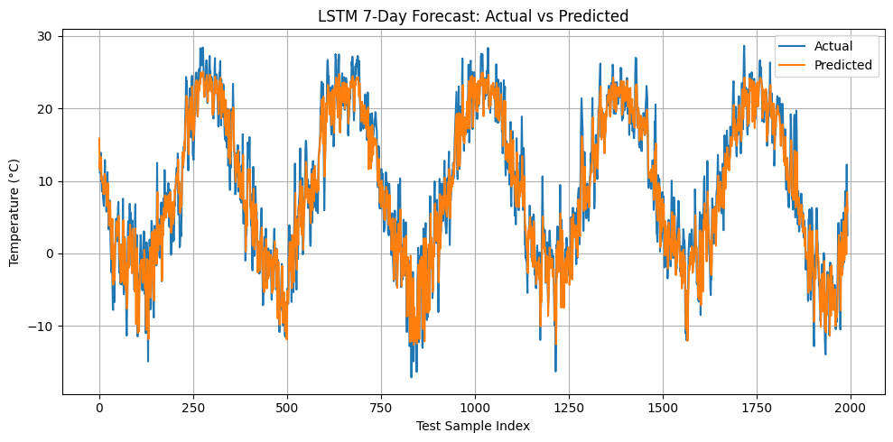

```python
import matplotlib.pyplot as plt

plt.figure(figsize=(10, 5))
plt.plot(y7_true, label='Actual')
plt.plot(y7_pred, label='Predicted')
plt.title("LSTM 7-Day Forecast: Actual vs Predicted")
plt.xlabel("Test Sample Index")
plt.ylabel("Temperature (°C)")
plt.legend()
plt.grid(True)
plt.tight_layout()
plt.savefig("lstm_7day.png")  # optional – saves the plot
plt.show()
```

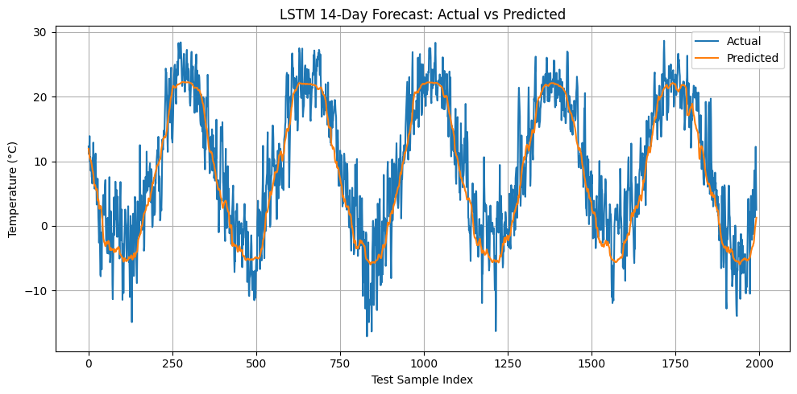

```python
plt.figure(figsize=(10, 5))
plt.plot(y14_true, label='Actual')
plt.plot(y14_pred, label='Predicted')
plt.title("LSTM 14-Day Forecast: Actual vs Predicted")
plt.xlabel("Test Sample Index")
plt.ylabel("Temperature (°C)")
plt.legend()
plt.grid(True)
plt.tight_layout()
plt.savefig("lstm_14day.png")
plt.show()
```

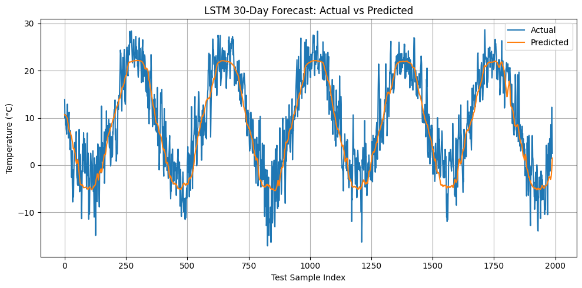

```python
plt.figure(figsize=(10, 5))
plt.plot(y30_true, label='Actual')
plt.plot(y30_pred, label='Predicted')
plt.title("LSTM 30-Day Forecast: Actual vs Predicted")
plt.xlabel("Test Sample Index")
plt.ylabel("Temperature (°C)")
plt.legend()
plt.grid(True)
plt.tight_layout()
plt.savefig("lstm_30day.png")
plt.show()
```

## 📊Final Model Comparison: Actual vs Predicted Plots

The following plots compare the predicted temperature with the actual recorded temperature on the test set. They show how each model evolves in accuracy and smoothness across time.

### 🧪 1. Baseline Linear Regression

- MAE: **4.39°C**, RMSE: **5.46°C**

[figure not shown]

### 🧪 2. Linear Model with Enhanced Features

- MAE: **3.86°C**, RMSE: **4.86°C**

[figure not shown]

### 🧪 3. First LSTM Model (Basic)

- MAE: **3.56°C**, RMSE: **4.50°C**

[figure not shown]

### 🧪 4. Final LSTM (Bidirectional + Dropout)

- MAE: **3.44°C**, RMSE: **4.36°C**

[figure not shown]

### 🌤️ 5. LSTM - 7 Day Horizon

[figure not shown]

### 🌤️ 6. LSTM - 14 Day Horizon

[figure not shown]

### 🌤️ 7. LSTM - 30 Day Horizon

[figure not shown]

### ✅ Takeaways:

- The LSTM models **outperform linear models** in capturing temporal patterns
- The **7-day LSTM model** clearly follows both short-term spikes and seasonal curves more closely
- **30-day forecasts** remain quite accurate, but show natural smoothing over longer horizons

# Commit Summary - Toronto Weather Forecasting: Model Evolution Summary

This notebook documents the step-by-step improvement of a machine learning pipeline to forecast Toronto’s daily temperature. Each commit added new features, model complexity, or data insights to improve accuracy, culminating in a high-performing deep learning solution.

## 🔁 Model Evolution

### 1️⃣ **Baseline Linear Regression**

- **Model**: Simple Dense Feedforward Regression
- **Features**: `avg_temperature`, `precipitation`, `humidity`
- **MAE**: **4.39°C**
- **RMSE**: **5.46°C**

### 2️⃣ **Enhanced Feature Linear Model**

- **Enhancements**: Added `sin_doy`, `cos_doy`, `DayOfYear`, `month`, `weekofyear`
- **MAE**: **3.86°C**
- **RMSE**: **4.86°C**

✅ ~**12% improvement** in MAE from baseline

### 3️⃣ **First LSTM Model**

- **Architecture**: 1-layer LSTM
- **Input**: 14 days of history
- **MAE**: **3.56°C**
- **RMSE**: **4.50°C**

✅ Showed ability to learn temporal sequences

### 4️⃣ **Improved LSTM**

- **Architecture**: Bidirectional + stacked LSTM + Dropout
- **MAE**: **3.44°C**
- **RMSE**: **4.36°C**

✅ ~**21.6% total MAE reduction** from baseline

## 🧠 Final LSTM Forecasting Models (Multi-Horizon)

[output not shown]